# Segregation Analysis with PySAL

```python
%load_ext watermark
```

```python
%watermark -v -a "author: eli knaap" -d -u -p segregation,libpysal,geopandas
```

```
author: eli knaap
last updated: 2020-07-09

CPython 3.7.6
IPython 7.15.0

segregation 1.2.0
libpysal 4.2.2
geopandas 0.8.0
```

Here, we'll use PySAL's `segregation` module to analyze racial segregation in southern california

```python
import geopandas as gpd
```

## Data Prep

```python
scag = gpd.read_file("data/scag_region.gpkg", layer="tracts")
```

We need to reproject the data into a more appropriate coordinate system. UTM11 should work

```python
scag = scag.to_crs(epsg=26911)
scag.crs
```

```
<Projected CRS: EPSG:26911>
Name: NAD83 / UTM zone 11N
Axis Info [cartesian]:
- E[east]: Easting (metre)
- N[north]: Northing (metre)
Area of Use:
- name: North America - 120°W to 114°W and NAD83 by country
- bounds: (-120.0, 30.88, -114.0, 83.5)
Coordinate Operation:
- name: UTM zone 11N
- method: Transverse Mercator
Datum: North American Datum 1983
- Ellipsoid: GRS 1980
- Prime Meridian: Greenwich
```

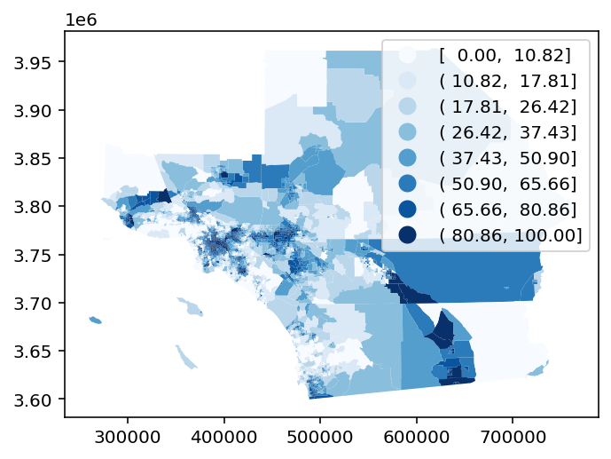

```python
scag.dropna(subset=['p_hispanic_persons']).plot(column='p_hispanic_persons',
                                                scheme='quantiles',
                                                cmap='Blues',
                                                k=8,
                                                legend=True)
```

some background on [fips codes](https://www.policymap.com/2012/08/tips-on-fips-a-quick-guide-to-geographic-place-codes-part-iii/)

```python
scag['county'] = scag.geoid.str[:5]
```

```python
scag.county.unique()
```

```
array(['06037', '06025', '06059', '06071', '06073', '06065', '06111'],
      dtype=object)
```

```python
county_names = ["Los Angeles", "Imperial", "Orange", "San Bernadino", "San Diego", "Riverside", "Ventura"]
```

```python
namer = dict(zip(scag.county.unique(), county_names))
```

```python
namer
```

```
{'06037': 'Los Angeles',
 '06025': 'Imperial',
 '06059': 'Orange',
 '06071': 'San Bernadino',
 '06073': 'San Diego',
 '06065': 'Riverside',
 '06111': 'Ventura'}
```

Now that we know which county is which, we could just use these codes to divide up the region into pieces. But lets go ahead and replace the codes with their names. It's more to type, but if we want to subset later, we won't have to go look up the codes again

```python
scag['county'] = scag.county.replace(to_replace=namer)
```

```python
scag.county
```

```
0       Los Angeles
1       Los Angeles
2       Los Angeles
3       Los Angeles
4       Los Angeles
           ...
4575    Los Angeles
4576    Los Angeles
4577        Ventura
4578      Riverside
4579    Los Angeles
Name: county, Length: 4580, dtype: object
```

```python
coastal = scag[scag.county.isin(["Los Angeles", "Orange", "San Diego", "Ventura"])]
```

```python
inland = scag[scag.county.isin(['Riverside', "San Bernadino", "Imperial"])]
```

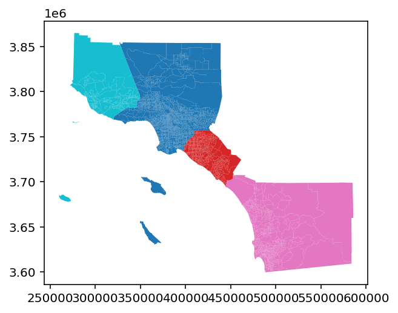

```python
coastal.plot(column='county')
```

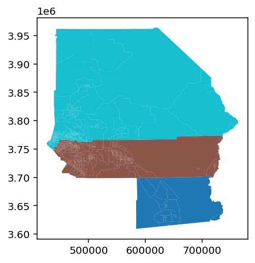

```python
inland.plot(column='county')
```

## Calculating Segregation Measures

### Classic (aspatial) Single-Group Indices

```python
from segregation.aspatial import Dissim, GiniSeg, Entropy
```

```python
dissim = Dissim(scag, "n_hispanic_persons", "n_total_pop")
gini = GiniSeg(scag, "n_hispanic_persons", "n_total_pop")
entropy = Entropy(scag, "n_hispanic_persons", "n_total_pop")
```

```python
dissim.statistic
```

```
0.4820197253710138
```

```python
gini.statistic
```

```
0.6368128074464425
```

```python
entropy.statistic
```

```
0.24939370275933018
```

### Multigroup Indices

```python
from segregation.aspatial import MultiInformationTheory, MultiGiniSeg, MultiDiversity
```

```python
pop_groups = ['n_asian_persons', 'n_hispanic_persons', 'n_nonhisp_black_persons', 'n_nonhisp_white_persons']
```

```python
multi_div = MultiDiversity(scag, pop_groups)
multi_info = MultiInformationTheory(scag, pop_groups)
```

```python
multi_div.statistic
```

```
1.1649555024744425
```

```python
multi_info.statistic
```

```
0.27621346024237237
```

### Spatial Indices

```python
from libpysal import weights
```

```python
from segregation.spatial import SpatialDissim,  SpatialInformationTheory
```

```python
w_queen = weights.Queen.from_dataframe(scag)
w_dist = weights.DistanceBand.from_dataframe(scag, 2500)
```

#### Single Group

```python
spatial_dissim = SpatialDissim(scag, 'n_hispanic_persons', 'n_total_pop', w=w_queen)
```

```python
spatial_dissim.statistic
```

```
0.35351598194379474
```

#### Multi Group

we can also look at how different concepts of space influence the resulting index statistic

```python
spatial_info_queen = SpatialInformationTheory(scag, pop_groups, w=w_queen)
spatial_info_dist = SpatialInformationTheory(scag, pop_groups, w=w_dist)
```

```python
spatial_info_queen.statistic
```

```
0.21447331455751437
```

```python
spatial_info_dist.statistic
```

```
0.21947469354446483
```

#### Multiscalar Profile

The multiscalar segregation profile is a way of measuring how global versus local the segregation patterns are in a region.

```python
from segregation.spatial import compute_segregation_profile
```

```python
distances = [1500., 2500., 3500., 4500., 5500.]
```

```python
prof = compute_segregation_profile(scag, pop_groups, distances)
```

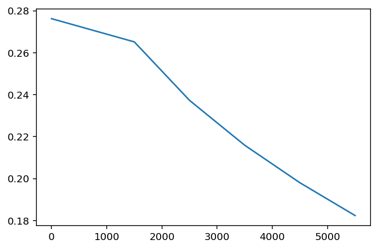

```python
import pandas as pd
pd.Series(prof).plot()
```

We can also look at how the segregation profiles differ by region. If we plot them all on the same graph, we can compare the slopes of the lines to see how the shape of segregation differs between places in the southern cal region

```python
coastal_prof = compute_segregation_profile(coastal, pop_groups, distances)
inland_prof = compute_segregation_profile(inland, pop_groups, distances)
```

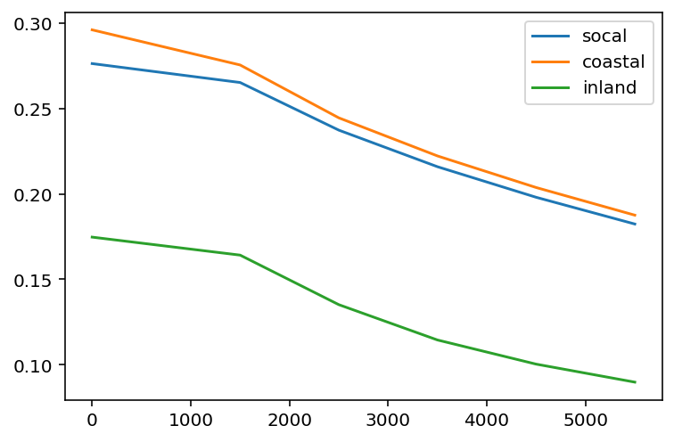

```python
pd.Series(prof, name='socal').plot(legend=True)
pd.Series(coastal_prof, name='coastal').plot(legend=True)
pd.Series(inland_prof, name='inland').plot(legend=True)
```

This shows that segregation in the coastal region is considerably larger than the inland region at every scale, though have similar shapes to their overall segregation profiles.

## Single-Value Inference

```python
from segregation.inference import SingleValueTest
```

```python
entropy_test = SingleValueTest(entropy)
```

```python
dissim_test = SingleValueTest(dissim)
```

```python
entropy_test.p_value
```

```
0.0
```

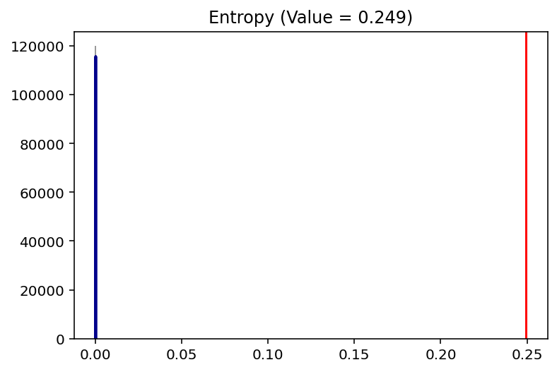

```python
entropy_test.plot()
```

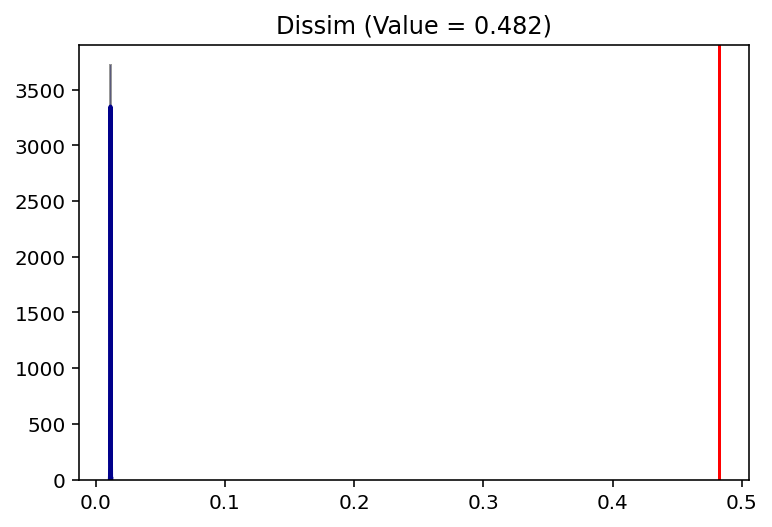

```python
dissim_test.plot()
```

## Comparative Inference

```python
from segregation.inference import TwoValueTest
```

```python
info_test = TwoValueTest(MultiInformationTheory(coastal, pop_groups),
            MultiInformationTheory(inland, pop_groups))
```

```python
info_test.est_point_diff
```

```
0.1212617149430146
```

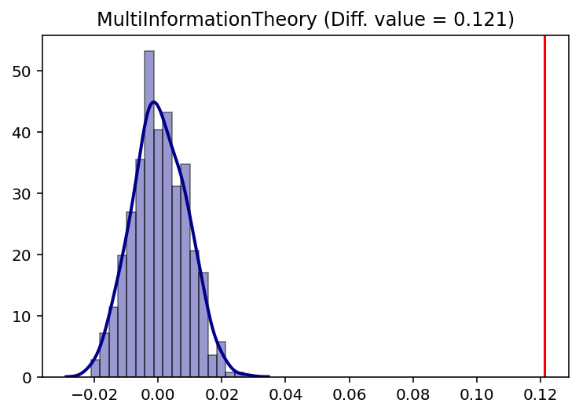

```python
info_test.plot()
```

## Decomposition

```python
from segregation.decomposition import DecomposeSegregation
```

```python
w_coastal = weights.DistanceBand.from_dataframe(coastal, 2000)
```

```python
w_inland = weights.DistanceBand.from_dataframe(inland, 2000)
```

```python
decomp = DecomposeSegregation(SpatialDissim(coastal, 'n_nonhisp_black_persons', 'n_total_pop', w=w_coastal),
                    SpatialDissim(inland,'n_nonhisp_black_persons', 'n_total_pop', w=w_inland))
```

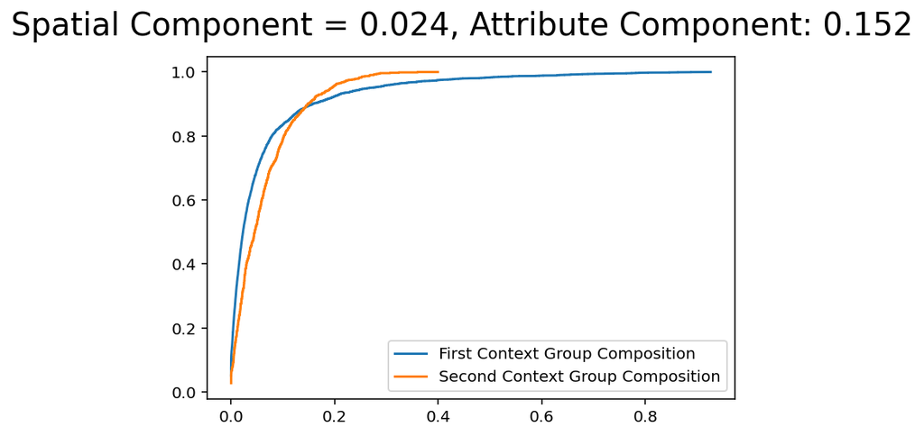

```python
decomp.plot()
```

## Exercise

1. Which county in the socal region has the greatest level of multiracial segregation, (using the 4 categories above) according to the MultiInformationTheory index?
2. According to the Gini index, is hispanic/latino segregation in Riverside County greater or less than Ventura County? Is that difference significant?
3. According to the Spatial Dissimilarity index, does the difference in segregation between Riverside and Venture result from the demograpic structure or the spatial structure?

```python
# %load solutions/06.py
```